# Golf balls assignment Modified

Paul M, Ziyi Jiang

1/6/2020

## Question

What is the distribution of these numbers? In particular, are the numbers 1, 2, 3, and 4 equally likely?

## Hypothesis and Statistics

First we should set up the hypothesis of this study.  
Let $x_i$ represents the frequency of i ball  
$H_0$: $x_1=x_2=x_3=x_4$  
$H_1$: any of the two are not equal

We will pick 486(137+138+104+107=486) numbers from the set {1,2,3,4} with equal probability and with replacement. Then we count the frequency of each of the four numbers. We will compute our statistics of interest. The whole process repeats for n=10000 times. At the end we will use p-value to determine whether we should reject our null hypothesis. And we will do the same for all three statistics of interest.

## Coding

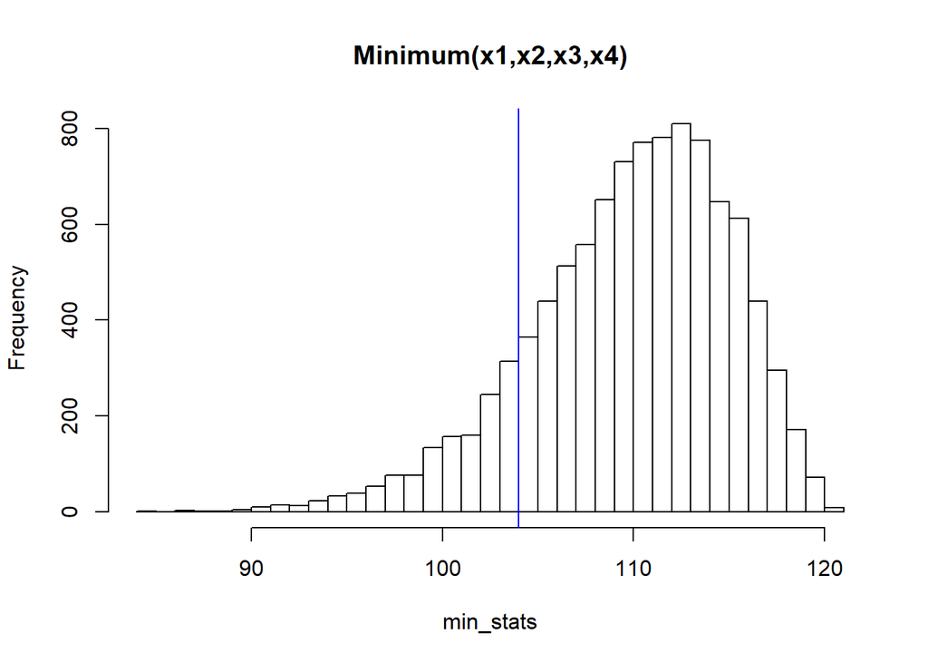

```r
# 996 is a meme among Chinese programmers
set.seed(996)

#total simulations
n<- 10000
#create 3 statistics
#each is a vector of numeric of length 10000
min_stats <- numeric(n)
max_stats <- numeric(n)
sd_stats <- numeric(n)

#these are data tallied by Allan Rossman
observation <- c(137, 138, 104, 107)

for (i in 1:n) {
  # we sample from {1,2,3,4} with replacement
  samp <- sample(1:4, 486, replace = TRUE)
  #simulation result
  # count how many 1,2,3,4
  sim_res <- c(sum(samp %in% 1), sum(samp %in% 2), sum(samp %in% 3), sum(samp %in% 4))

  #fill out all three statistics
  min_stats[i] <- min(sim_res)
  max_stats[i] <- max(sim_res)
  sd_stats[i] <- sqrt(sum(((sim_res - mean(sim_res))**2)) / length(sim_res))
}



#1st statistics

ob_min <- min(observation)
hist(min_stats, breaks = 50, main = "Minimum(x1,x2,x3,x4)")
abline(v = ob_min, col = "blue")
```

```r
#What percentage of the generated min_stats are actually less than our observed min
p_val1 <- sum(min_stats <= ob_min) / n
#print out p value
cat("p value for min statistics is: ",p_val1)
```

```
## p value for min statistics is:  0.1364
```

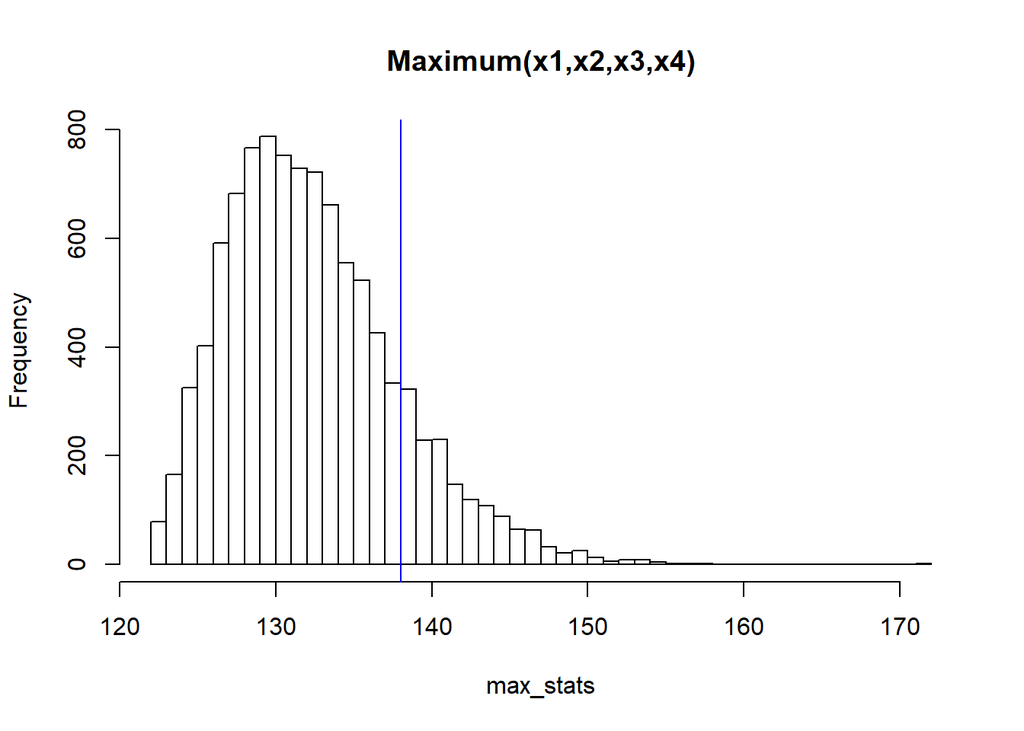

```r
#2nd statistics
ob_max <- max(observation)
hist(max_stats, breaks = 50, main = "Maximum(x1,x2,x3,x4)")
abline(v = ob_max, col = "blue")
```

```r
#What percentage of the generated max_stats are actually greater than our observed max
p_val2 <- sum(max_stats >= ob_max) / n

cat("p value for max statistic is : ",p_val2)
```

```
## p value for max statistic is :  0.183
```

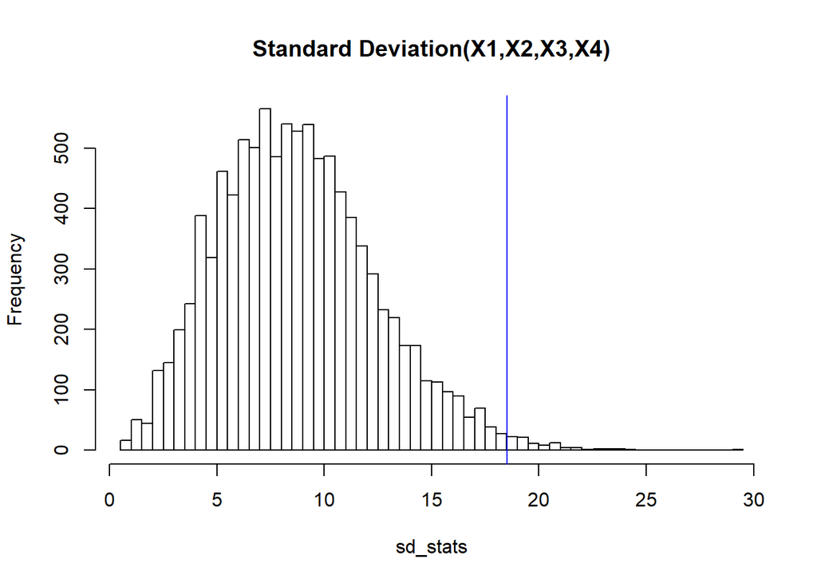

```r
#3rd statistics
ob_sd <- sd(observation)
hist(sd_stats,breaks=50 ,main = "Standard Deviation(X1,X2,X3,X4)")
abline(v = ob_sd, col = "blue")
```

```r
# what percentage of the generated standard deviations are larger
p_val3 <- sum(sd_stats >= ob_sd) / n

cat("p value for SD statistic is: ", p_val3)
```

```
## p value for SD statistic is:  0.0088
```

## Final Conclusion

Now we have the p-value from hypothesis testing. Min and max statistics both have p-values(0.136 and 0.183) greater than the threshold 0.05. We cannot reject the null hypothesis that four balls have the same frequency by using these two statistics. Standard deviation provides us a very small p-value(0.0088<0.05). We can reject the null hypothesis based on that.